# Peer-graded Assignment: Prediction Assignment Writeup

Stefanvr001

14 June 2018

### Peer-graded Assignment: Prediction Assignment Writeup

#### Background

The goal of your project is to predict the manner in which they did the exercise. This is the “classe” variable in the training set. You may use any of the other variables to predict with. You should create a report describing how you built your model, how you used cross validation, what you think the expected out of sample error is, and why you made the choices you did. You will also use your prediction model to predict 20 different test cases.

#### Peer Review Portion

Your submission for the Peer Review portion should consist of a link to a Github repo with your R markdown and compiled HTML file describing your analysis. Please constrain the text of the writeup to < 2000 words and the number of figures to be less than 5. It will make it easier for the graders if you submit a repo with a gh-pages branch so the HTML page can be viewed online (and you always want to make it easy on graders :-).

#### Course Project Prediction Quiz Portion

Apply your machine learning algorithm to the 20 test cases available in the test data above and submit your predictions in appropriate format to the Course Project Prediction Quiz for automated grading.

#### Description of work

I loaded the data and inspected the structure and contents of the column variables (Code will follow below). Upon inspection there were various columns that had NA values. After looking at how densly populated the columns were I decided to drop a lot of variables with missing values.

There after I did a principal component analysis and saw that approx. 99% of the variance can be explained with 7 variables.

I set out with the goal of trying 3 methods for prediction and if anyone didn’t provide a relatively good accuracy level that I would try stacking models for a better fit. I didn’t need to go that route after trying the 3rd model.

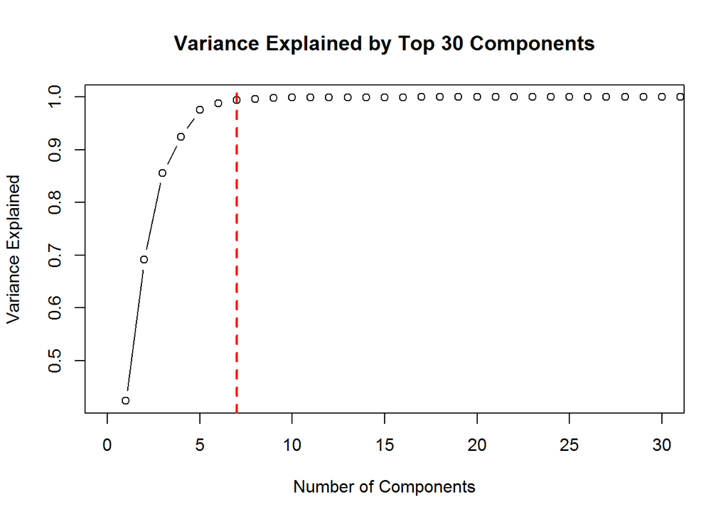

```r
library(caret)
library(ggplot2)
library(rattle)
options(digits = 5)

setwd("~/R/R Exercises/Coursera/Course8")

train<-read.csv("pml-training.csv", stringsAsFactors = FALSE)
test<-read.csv("pml-testing.csv", stringsAsFactors = FALSE)

for(i in 8:159){
  train[,i]<-as.numeric(train[,i])
}
for(i in 8:159){
  test[,i]<-as.numeric(test[,i])
}


### MEANS
classeIndicatorsMean<-as.data.frame(matrix(0,nrow = length(unique(train$classe)), ncol = 160-8))
names(classeIndicatorsMean)<-paste0(names(train)[8:159], "_MEAN")
classeIndicatorsMean$classe<-unique(train$classe)

for(i in 1:length(unique(train$classe))){
  index<-which(train$classe == classeIndicatorsMean$classe[i])
  temp<-train[index,-c(1:7,160)]
  vec<-colMeans(temp, na.rm = TRUE)
  classeIndicatorsMean[i,-153]<-vec
}

### NA VALS
classeIndicatorsNA<-as.data.frame(matrix(0,nrow = length(unique(train$classe)), ncol = 160-8))
names(classeIndicatorsNA)<-paste0(names(train)[8:159], "_NA")
classeIndicatorsNA$classe<-unique(train$classe)


for(i in 1:length(unique(train$classe))){
  index<-which(train$classe == classeIndicatorsNA$classe[i])
  temp<-train[index,-c(1:7,160)]
  for(j in 1:dim(temp)[2]){
    index2<-length(which(is.na(temp[,j])))/length(temp[,j])
    classeIndicatorsNA[i,j]<-index2
  }
}

vec<-colMeans(classeIndicatorsNA[,-153])
index<-which(vec>0.5)
vec<-vec[index]

vec2<-which(paste0(names(train),"_NA") %in% names(vec))
train2<-train[,-vec2]

vec2<-which(paste0(names(test),"_NA") %in% names(vec))
test2<-test[,-vec2]


covtrain2_pca <- cov(train2[,c(8:59)])
train2_pca <- prcomp(covtrain2_pca)
varex <- train2_pca$sdev^2/sum(train2_pca$sdev^2)
varcum <- cumsum(varex)
result <- data.frame(num=1:length(train2_pca$sdev), ex=varex, cum=varcum)

plot(result$num,result$cum,type="b",xlim=c(0,30),
     main="Variance Explained by Top 30 Components",
     xlab="Number of Components",ylab="Variance Explained")
abline(v=7,lty=2, col='red', lwd=2)
```

```r
### Drop some more variables
train3<-train2[,-c(1:7)]
test3<-test2[,-c(1:7)]
```

#### Summary of results

I used the following methods from the caret package: RPart, Random Forest and Gradient Boosting.

The best results came from the using Gradient Boosting and Random Forest. The Random Forest produced the best accuracy (99%), but at the cost of nearly 4hours spent training the model. On the other hand, the GBM produced 96% accuracy while only taking about 15 minutes to train the model.

The choice of the model will depend on the user’s preference and the requirement for the task at hand.

```r
### BUILD MODELS
set.seed(101)
intrain<-createDataPartition(train3$classe, p=0.7, list = FALSE)
trainingSet<-train3[intrain,]
testingSet<-train3[-intrain,]

### RPART
modelfitRP<-train(classe ~., method='rpart', data=trainingSet)
#fancyRpartPlot(modelfitRP$finalModel)

### Train accuracy
predictCatRP<-predict(modelfitRP, newdata = trainingSet)
errorRateRP<-which(trainingSet$classe != predictCatRP)

cat("Train Accuracy for RPart method: ", round((1-length(errorRateRP)/length(trainingSet$classe))*100,2), "%","\n")
```

```
## Train Accuracy for RPart method:  49.71 %
```

```r
### Test accuracy
predictCatRP<-predict(modelfitRP, newdata = testingSet)
errorRateRP<-which(testingSet$classe != predictCatRP)
cat("Test Accuracy for RPart method: ", round((1-length(errorRateRP)/length(testingSet$classe))*100,2), "%","\n")
```

```
## Test Accuracy for RPart method:  49.62 %
```

```r
cat("Misclassification areas for RPart method: (Rows = Actuals; Columns = Predictions) ","\n")
```

```
## Misclassification areas for RPart method: (Rows = Actuals; Columns = Predictions)
```

```r
prop.table(table(testingSet$classe, predictCatRP))*100
```

```
##    predictCatRP
##             A         B         C         D         E
##   A 25.539507  0.560748  2.276975  0.000000  0.067969
##   B  7.884452  6.694987  4.774851  0.000000  0.000000
##   C  8.105353  0.747664  8.581138  0.000000  0.000000
##   D  7.357689  3.024639  5.998301  0.000000  0.000000
##   E  2.497876  2.565845  4.519966  0.000000  8.802039
```

```r
cat("Notes on the model: ","\n",
    "- The model is very stable in prediction accuracy between train and test sets; ","\n",
    "- The model is very quick to run; ","\n",
    "- The model doesn't predict the categories B,C and D well at all. ","\n")
```

```
## Notes on the model:
##  - The model is very stable in prediction accuracy between train and test sets;
##  - The model is very quick to run;
##  - The model doesn't predict the categories B,C and D well at all.
```

```r
### RANDOM FOREST
modelfitRF<-train(classe ~., method='rf', data=trainingSet, prox=TRUE)
predictvalsRF<-predict(modelfitRF, newdata = testingSet)

### Train accuracy
predictCatRF<-predict(modelfitRF, newdata = trainingSet)
errorRateRF<-which(trainingSet$classe != predictCatRF)
cat("Train Accuracy on RandomForest: ", round((1-length(errorRateRF)/length(trainingSet$classe))*100,2), "%","\n")
```

```
## Train Accuracy on RandomForest:  100 %
```

```r
### Test accuracy
predictCatRF<-predict(modelfitRF, newdata = testingSet)
errorRateRF<-which(testingSet$classe != predictCatRF)
cat("Test Accuracy on RandomForest: ", round((1-length(errorRateRF)/length(testingSet$classe))*100,2), "%","\n")
```

```
## Test Accuracy on RandomForest:  99.3 %
```

```r
prop.table(table(testingSet$classe, predictCatRF))*100
```

```
##    predictCatRF
##             A         B         C         D         E
##   A 28.377230  0.033985  0.016992  0.000000  0.016992
##   B  0.135939 19.116398  0.101954  0.000000  0.000000
##   C  0.000000  0.067969 17.332201  0.033985  0.000000
##   D  0.000000  0.000000  0.101954 16.227698  0.050977
##   E  0.000000  0.000000  0.033985  0.101954 18.249788
```

```r
cat("Notes on the model: ","\n",
    "- The model is very stable in prediction accuracy between train and test sets; ","\n",
    "- The model takes extremely long to run; ","\n",
    "- The model produces better results than the RPart method for all categories. ","\n")
```

```
## Notes on the model:
##  - The model is very stable in prediction accuracy between train and test sets;
##  - The model takes extremely long to run;
##  - The model produces better results than the RPart method for all categories.
```

```r
### GBM
modelfitGBM<-train(classe ~., method='gbm', data=trainingSet, verbose=FALSE)
predictvalsGBM<-predict(modelfitGBM, newdata = testingSet)

### Train accuracy
predictCatGBM<-predict(modelfitGBM, newdata = trainingSet)
errorRateGBM<-which(trainingSet$classe != predictCatGBM)
cat("Train Accuracy for GBM: ", round((1-length(errorRateGBM)/length(trainingSet$classe))*100,2), "%","\n")
```

```
## Train Accuracy for GBM:  97.44 %
```

```r
### Test accuracy
predictCatGBM<-predict(modelfitGBM, newdata = testingSet)
errorRateGBM<-which(testingSet$classe != predictCatGBM)
cat("Test Accuracy for GBM: ", round((1-length(errorRateGBM)/length(testingSet$classe))*100,2), "%","\n")
```

```
## Test Accuracy for GBM:  96.06 %
```

```r
prop.table(table(testingSet$classe, predictCatGBM))*100
```

```
##    predictCatGBM
##             A         B         C         D         E
##   A 27.765506  0.441801  0.152931  0.067969  0.016992
##   B  0.730671 17.994902  0.577740  0.050977  0.000000
##   C  0.000000  0.509771 16.737468  0.169924  0.016992
##   D  0.000000  0.084962  0.407816 15.734919  0.152931
##   E  0.033985  0.169924  0.084962  0.271878 17.824979
```

```r
cat("Notes on the model: ","\n",
    "- The model is very stable in prediction accuracy between train and test sets; ","\n",
    "- The model is quite quick to run; ","\n",
    "- The model produces great results for all categories. ","\n")
```

```
## Notes on the model:
##  - The model is very stable in prediction accuracy between train and test sets;
##  - The model is quite quick to run;
##  - The model produces great results for all categories.
```

```r
## SECOND TEST SET
predictCatGBM2<-predict(modelfitGBM, newdata = test3)
write.csv(predictCatGBM2, "testPredictions.csv")
```